# Are Richer Countries More Equal? Income Inequality and GDP per Capita

Trang Nguyen

07 November 2026

# 1 Loading libraries

# 2 Research question

Do countries with a higher GDP per capita have lower income inequality? We also ask whether this relationship looks the same across world regions.

# 3 Data set introduction

The data come from the [Income inequality vs. GDP per capita](https://ourworldindata.org/grapher/gini-coefficient-vs-gdp-per-capita-pip) chart published by Our World in Data, which combines World Bank poverty and inequality estimates with GDP per capita figures. For each country, I kept the most recent year between 2015 and 2024 in which both inequality and GDP per capita were available.

The variables `country` and `region` record each country’s name and its world region. The variable `year` is the year of the latest inequality survey, and `gini` is the Gini coefficient, which ranges from 0 (everyone has the same income) to 1 (one person has all the income). The variable `gdp_per_capita` is GDP per person, adjusted for inflation and for differences in living costs between countries (international-$).

```r
gini_gdp <- read_csv("Data/gini_gdp.csv")
```

```r
variable_info <- tibble(
  Variable = names(gini_gdp),
  Description = c(
    "Country name",
    "World region (Our World in Data definition)",
    "Year of the most recent inequality survey",
    "Gini coefficient of income or consumption (0 to 1)",
    "GDP per capita (international-$, adjusted for inflation)"
  )
)

kable(variable_info, caption = "Variables in the data set")
```

Variables in the data set

| Variable | Description |
| --- | --- |
| country | Country name |
| region | World region (Our World in Data definition) |
| year | Year of the most recent inequality survey |
| gini | Gini coefficient of income or consumption (0 to 1) |
| gdp_per_capita | GDP per capita (international-$, adjusted for inflation) |

# 4 Data set description

The data set contains 149 observations and 5 variables.

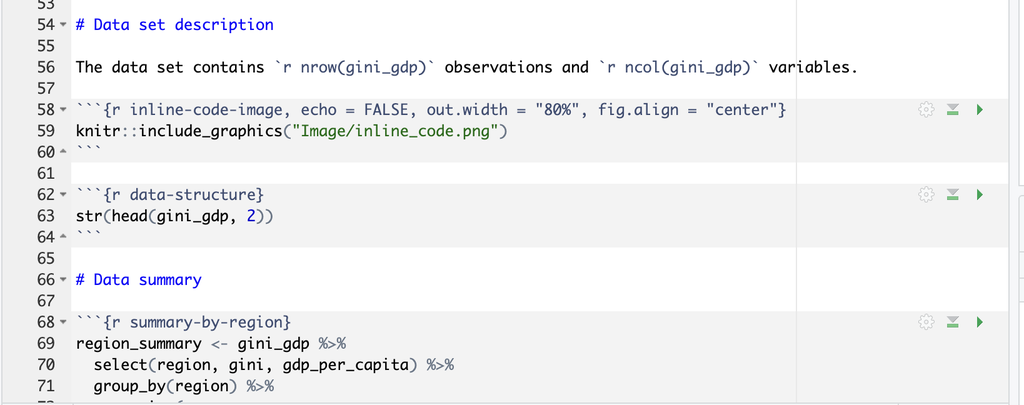

```r
knitr::include_graphics("Image/inline_code.png")
```

```r
str(head(gini_gdp, 2))
```

```
## tibble [2 × 5] (S3: tbl_df/tbl/data.frame)
##  $ country       : chr [1:2] "Albania" "Angola"
##  $ region        : chr [1:2] "Europe" "Africa"
##  $ year          : num [1:2] 2020 2018
##  $ gini          : num [1:2] 0.294 0.513
##  $ gdp_per_capita: num [1:2] 16458 10155
```

# 5 Data summary

```r
region_summary <- gini_gdp %>%
  select(region, gini, gdp_per_capita) %>%
  group_by(region) %>%
  summarise(
    mean_gini = mean(gini),
    sd_gini = sd(gini),
    mean_gdp = mean(gdp_per_capita),
    sd_gdp = sd(gdp_per_capita)
  ) %>%
  arrange(desc(mean_gdp))

kable(
  head(region_summary, 10),
  digits = c(0, 3, 3, 0, 0),
  format.args = list(big.mark = ","),
  col.names = c("Region", "Mean Gini", "SD Gini",
                "Mean GDP per capita", "SD GDP per capita"),
  caption = paste("Mean and standard deviation of the Gini coefficient",
                  "and GDP per capita by world region")
)
```

Mean and standard deviation of the Gini coefficient and GDP per capita by world region

| Region | Mean Gini | SD Gini | Mean GDP per capita | SD GDP per capita |
| --- | --- | --- | --- | --- |
| Europe | 0.308 | 0.038 | 48,902 | 25,453 |
| North America | 0.421 | 0.054 | 25,303 | 19,666 |
| Asia | 0.329 | 0.044 | 22,327 | 22,978 |
| South America | 0.441 | 0.052 | 19,625 | 7,067 |
| Oceania | 0.307 | 0.041 | 15,136 | 20,927 |
| Africa | 0.398 | 0.073 | 6,647 | 6,710 |

Europe is by far the richest region on average and, together with Oceania, has the **lowest** average Gini coefficient (about 0.31). South America is the most unequal region (mean Gini of about 0.44) even though its average income is lower than Asia’s, while Africa is the poorest region but not the most unequal.

To check whether the overall pattern holds inside each region, the correlation table below shows the correlation between log GDP per capita and the Gini coefficient within each region.

```r
region_correlation <- gini_gdp %>%
  group_by(region) %>%
  summarise(
    countries = n(),
    correlation = cor(log(gdp_per_capita), gini)
  ) %>%
  arrange(correlation)

kable(
  region_correlation,
  digits = 2,
  col.names = c("Region", "Number of countries",
                "Correlation (log GDP vs Gini)"),
  caption = paste("Correlation between log GDP per capita and the",
                  "Gini coefficient within each region")
)
```

Correlation between log GDP per capita and the Gini coefficient within each region

| Region | Number of countries | Correlation (log GDP vs Gini) |
| --- | --- | --- |
| North America | 14 | -0.17 |
| Europe | 41 | -0.11 |
| South America | 9 | -0.04 |
| Africa | 46 | 0.15 |
| Asia | 33 | 0.20 |
| Oceania | 6 | 0.47 |

Within most regions the correlation is close to zero, and in Africa and Asia it is even positive, meaning richer countries there are slightly more unequal. Oceania’s value is based on only six countries, so it is not reliable. This suggests that the weak global relationship mainly reflects differences between regions rather than a pattern that holds inside each region.

# 6 Visualisations

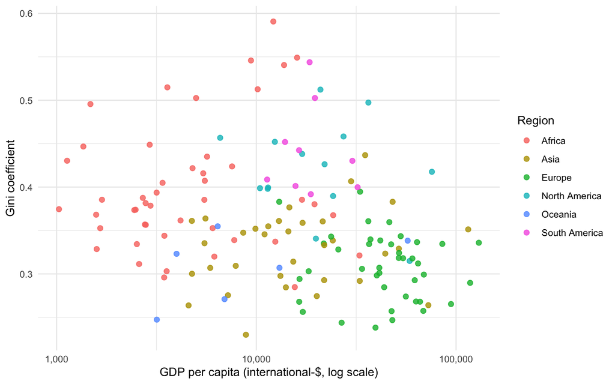

Gini coefficient against GDP per capita (log scale) for each country, coloured by world region.

```r
ggplot(gini_gdp, aes(x = gdp_per_capita, y = gini, colour = region)) +
  geom_point(size = 2, alpha = 0.8) +
  scale_x_log10(labels = scales::label_comma()) +
  labs(
    x = "GDP per capita (international-$, log scale)",
    y = "Gini coefficient",
    colour = "Region"
  ) +
  theme_minimal()
```

- *Richer countries tend to have slightly lower inequality, but the points are widely spread and the correlation between log GDP per capita and the Gini coefficient is only -0.26.*
- *Countries group by region more than by income: European countries sit at the bottom of the chart, while South and North American countries sit higher at similar income levels.*

The boxplot below compares the spread of the Gini coefficient within each region.

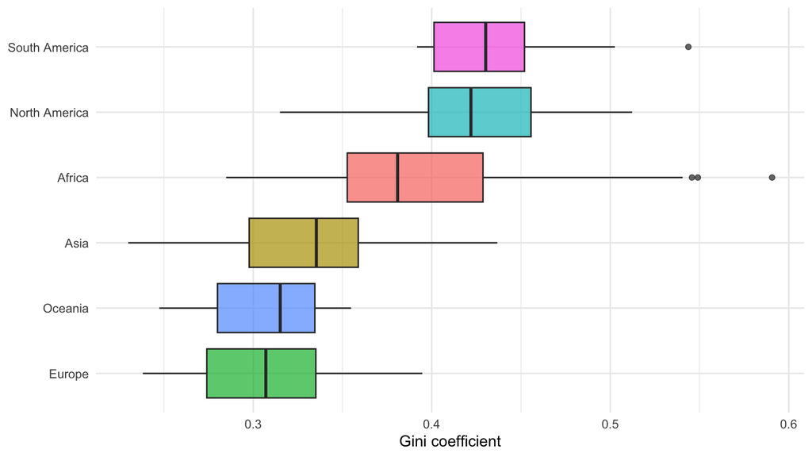

Distribution of the Gini coefficient by world region, ordered by median.

```r
ggplot(gini_gdp,
       aes(x = reorder(region, gini, FUN = median), y = gini, fill = region)) +
  geom_boxplot(alpha = 0.7, show.legend = FALSE) +
  coord_flip() +
  labs(x = NULL, y = "Gini coefficient") +
  theme_minimal()
```

Europe has the lowest median, while South and North America have the highest medians. Africa shows the widest spread, from fairly equal to very unequal countries, so its regional average hides large differences between countries.

# 7 Conclusions

The data give only weak support to the idea that richer countries are more equal. Across all countries, higher GDP per capita goes together with a slightly lower Gini coefficient, but within most regions this link almost disappears. The global pattern is mainly driven by differences between regions: Europe is both rich and equal, the Americas are unequal at many income levels, and Africa shows the widest range of inequality. These results show an association, not a cause. Tax and welfare systems, history and how inequality is measured (income in some countries, consumption in others) could explain the pattern, and survey years differ between countries. Future work could add these factors to test which ones best explain inequality.

*AI-use acknowledgement: Generative AI assisted with checking the supplied reference against the assessment requirements, adjusting R Markdown chunk options, rendering the report, and preparing the project archive and Git history.*